# Epistemische Überzeugungen Lehramtsstudierender

## Inhaltlicher und organisatorischer Überblick

- Einführung
- Epistemische Überzeugungen
  - Definitionen
  - Konzeptualisierungen
  - kritische Diskussion
- Synopse zentraler Befunde
  - Epistemische Überzeugungen sind **dualer Natur**
  - Epistemische Überzeugungen **kalibrieren die Lernstrategienwahl**
  - Epistemische Überzeugungen **sind funktional für das Interesse an/die Praxisrelevanzeinschätzung von** bildungswissenschaftlichem Wissen
- Ausblick

Die interaktiven Folien können unter https://merk.shinyapps.io/mindthegap und deren Quellcode unter https://github.com/sammerk/Disputation abgerufen werden

## Epistemische Überzeugungen

## Zugänge zur Begrifflichkeit I

- **Ethymologie**
  - Episteme = Erkenntnis, Wissen, Wissenschaft
  - Logos = Wissenschaft, Lehre (Meidl, 2009)
- **Konvention**
  - Epistemologie = Wissenschaftstheorie, -lehre; Erkenntnistheorie, -lehre (Auberle et al., 2011)
- **Wörtliche Übersetzung**
  - epistemologische Überzeugung = Überzeugung die Wissenschaftstheorie betreffend
  - epistemische Überzeugungen = wissenschaftstheoretische Entitäten betreffende Überzeugung (Kitchener, 2002)

## Zugänge zur Begrifflichkeit II

- **In Überblicksarbeiten**
  - Definition I: *[…] refers to what individuals think knowledge is and how they think that they and others know.* (Hofer & Bendixen, 2012)
  - Definition II: *[…] refers to the theories or beliefs that students (and other individuals) hold about knowledge and the process of knowing.* (Bråten, 2010)
- **"Epistemic Somethings" vs "epistemologische Überzeugungen"**

[figure not shown]

- **Arbeitsdefinition:** Überzeugungen bzgl. der Natur und Genese von Wissen

## Überblick zentraler Konzeptualisierungen

[interactive chart not shown]

## Konzeptuelle und methodologische Kritik

- Inhaltsvalidität (Hartig, Frey, & Jude, 2008)
  - **Dimensionale Konzeptualisierungen:** Definition der Dimensionen, **epistemischer** Charakter der Items (Bromme & Haag, 2008; Schommer, 1990; Stahl, 2011)
  - **Positionale Konzeptualisierungen:** Sind Streitfragen/Interviewstimuli geeignet, epistemische Überzeugungen *exklusiv, exhaustiv und in ausgewogenem Verhältnis* (Hartig et al., 2008, S. 152) abzubilden?
- Konstruktvalidität (Messick, 1995)
  - **Dimensionale Konzeptualisierungen:**
    - Faktorenstruktur wird selten überprüft/entspricht selten den Annahmen (Hofer & Pintrich, 1997; Muis, Bendixen, & Haerle, 2006; Priemer, 2006)
    - Interpretation der Faktoren als naiv–sophistiziert Kontinuum kann problematisch sein (Elby & Hammer, 2001; Klopp & Stark, 2014; Peter, Rosman, Mayer, & Leichner, 2015; Stahl, 2011)
  - **Positionale Konzeptualisierungen:**
    - Allg. Kritik an der Eindimensionalitätsannahme (Hofer & Pintrich, 1997; Limón, 2006; Priemer, 2006)
    - Operationalisierung widerspricht in vielen Fällen der Eindimensionalitätsannahme (Barzilai & Eshet-Alkalai, 2015; King & Kitchener, 1994; Krettenauer, 2004; Kuhn, Cheney, & Weinstock, 2000; Peter et al., 2015)

## Duale Natur epistemischer Überzeugungen Lehramtsstudierender

## Duale Natur: Rahmenmodell

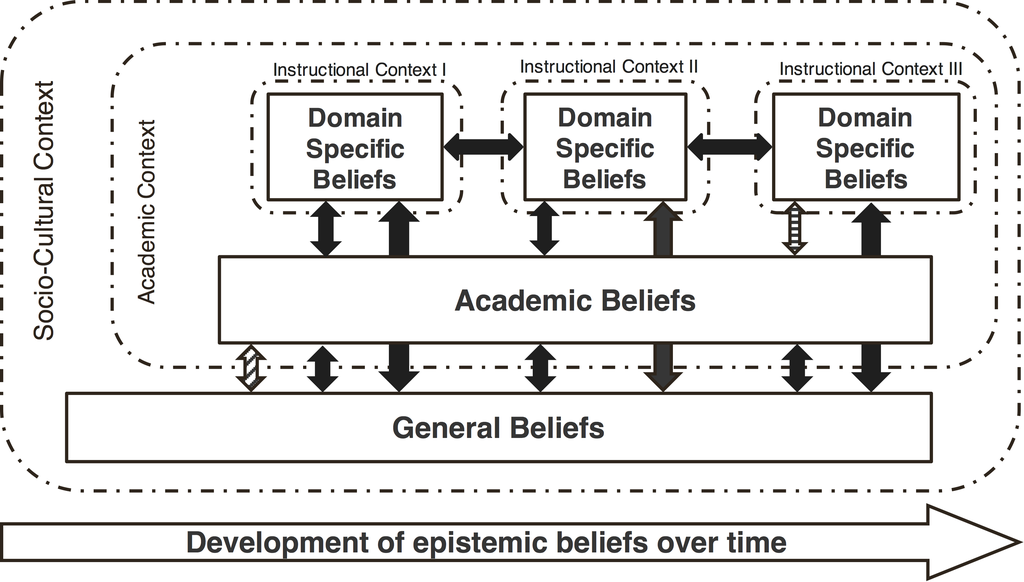

Abb. 1: Theory of Integrated Domains in Epistemology. Abb. nach (Muis et al., 2006, S. 30).

## Duale Natur: Forschungsstand

- Es wird entweder within- oder between-person Domänenspezifität untersucht (Buehl, Alexander, & Murphy, 2002; Muis et al., 2006)
- Ergebnisse einer einschlägigen Review von Muis, Bendixen, & Haerle (2006)

  - |  | within-design | between-design |
    | --- | --- | --- |
    | Domänenspezifität | 4 | 8 |
    | Domänengeneralität | 1 | 0 |
    | Duale Natur | 6 | 0 |

- Kritik: Theoretische Einbettung unklar; Untersuchungsdesigns teilw. inadäquat (Limón, 2006; Merk, Schneider, Syring, & Bohl, eingereicht_c; Trautwein & Lüdtke, 2004)

## Duale Natur: Eigene Befunde

- Between-person Differenzen in epistemischen Überzeugungen zu bildungswissenschaftlichem Wissen sind sowohl aus dimensionaler (Merk, Muis, Kelava, & Bohl, eingereicht_b) als auch aus positionaler (Merk, Kelava, Schneider, Syring, & Bohl, eingereicht_a; Merk et al., eingereicht_c) und personaler (Merk, 2013) Perspektive eher kleiner oder moderater Größe
- Within-person Variation in epistemischen Überzeugungen ist sowohl über verschiedene Disziplinen (Merk et al., eingereicht_c) als auch innerhalb der Bildungswissenschaften (Merk et al., eingereicht_a, b) erheblich
- Kontexte scheinen eine wesentlich geringere Rolle zu spielen als der Gegenstand selbst (Merk et al., eingereicht_a)

## Duale Natur: Interaktives Datenbeispiel

[interactive chart not shown]

## Duale Natur: Modellierung

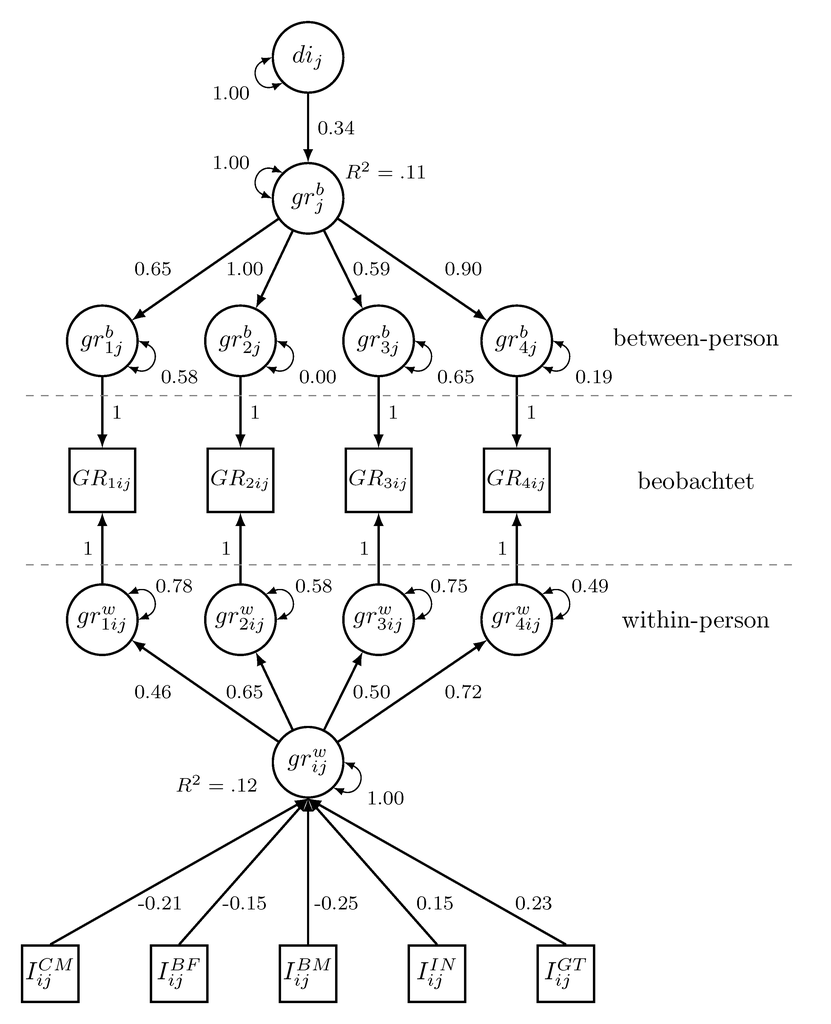

## Die Kalibrierungshypothese

## Die Kalibrierungshypothese I

- Erweiterung des klassischen Kalibrierungsbegriffs (Alexander, 2013; Nelson & Dunlosky, 1991) durch Stephanie Pieschl (Pieschl, 2009)

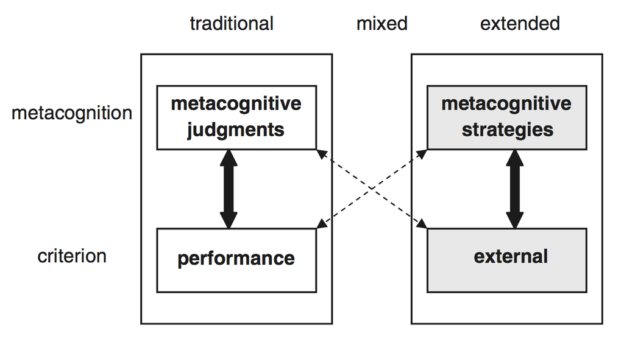

Abb. 4: Erweiterte Definition des Kalibrierungsbegriffs nach (Pieschl, 2009). Abbildung (ebd. S. 16).

## Die Kalibrierungshypothese II

- Kalibrierende Wirkung epistemischer Überzeugungen als "Linsenfunktion" (Bromme, Pieschl, & Stahl, 2010)

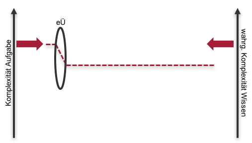

## Kalibrierungshypothese: Eigener Befund

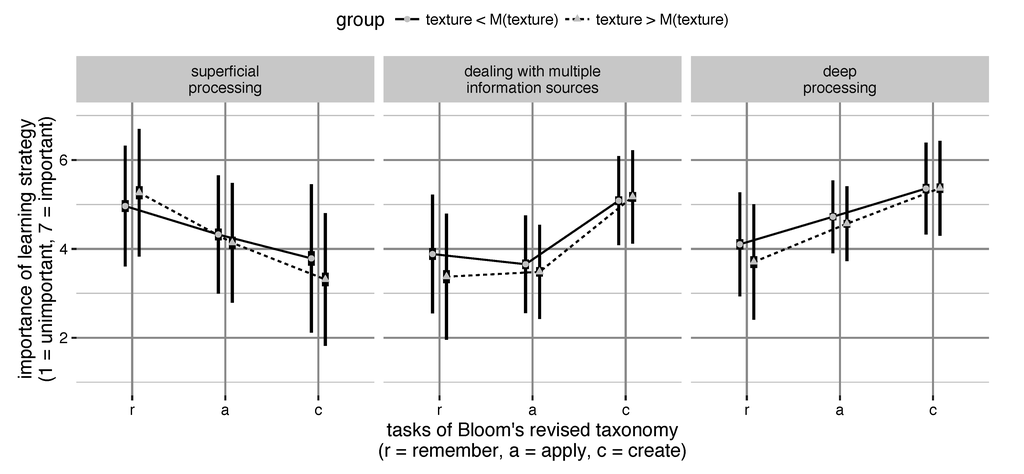

Abb. 6: Stichprobe: *N* = 805 Lehramtsstudierende im Grundstudium; Material: Drei Aufgaben unterschiedlicher Komplexität (revidiert) nach Bloom (Anderson & Krathwohl, 2001), COPES-Questionaire (Pieschl, 2008), CAEB (Stahl, Pieschl, & Bromme, 2006).

## Epistemische Überzeugungen und Professionalität

## Epistemische Überzeugungen und Professionalität

- Explizitem Bezug der Forschung zu epistemischen Überzeugungen auf die Professionalisierungsforschung wird vielfach hohes Potential zugemessen (Baumert & Kunter, 2006; Bromme, 1992; Hofer & Sinatra, 2010, 2010; Muis, 2004; Olafson, Schraw, & Vander Veldt, 2010; Tsai, 2007)
- Dieser Forderung folgend, wurde eine Verhältnisbestimmung innerhalb des deutschsprachigen Diskurses vorgenommen
- Und infolge dessen insbesondere die Rolle epistemischer Überzeugungen für die Wahrnehmung der Theorie-Praxis-Integration untersucht

## Epistemische Überzeugungen und Professionalität: Eigene Befunde

- Epistemische Überzeugungen prädizieren die Bedeutsamkeitseinschätzungen von pädagogischem und fachidaktischem Wissen für den (KMK-)Kompetenzerwerb bei Referendarinnen und Referendaren (Merk, Cramer, & Bohl, 2016)
- Epistemische Überzeugungen prädizieren die Theorie-Praxis-Integration bildungswissenschaftlicher Gegenstände nach Kontrolle motivationaler und affektiver Variablen (Merk, Pucite, Schneider, Syring, & Bohl, 2016)

## Interaktives Datenbeispiel

[interactive chart not shown]

## Ergebnisse aus Mehrebenenstrukturgleichungsmodellierung

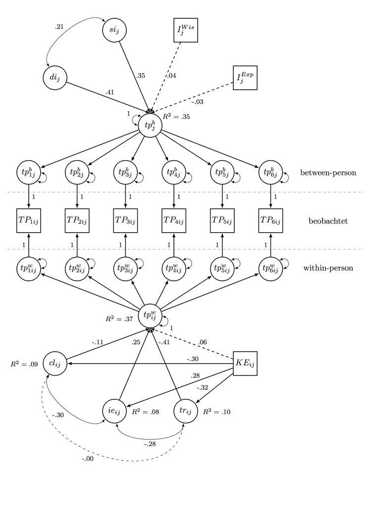

## Ausblick

- Replikation der Befunde zum Theorie-Praxis-Verhältnis auf Large-Scale-Daten (BILWIS)
- Epistemische Emotionen, epistemische Vertrauenswürdigkeit?
- Effekte einer Offenlegung des epistemologischen Status und der Erkenntnismethode bildungswissenschaftlicher Gegenstände?
- Epistemische Überzeugungen als notwendige/hinreichende Bedingung der Professionalitätsentwicklung?

## Anhang

## Kalibrierungshypothese: Rahmenmodell

[figure not shown]

Abb. 3: Das COPES-Modell selbstregulierten Lernens. Abb. nach (Winne & Hadwin, 1998)

## Epistemische Überzeugungen und Professionalität II

### Verhältnisbestimmung innerhalb des deutschsprachigen Diskurses

- Kompetenztheoretischer Ansatz
  - eÜ sind generischer Bestandteil
  - **Filter, Framing** und **Guiding** Funktionalität (Fives & Buehl, 2012) auch innerhalb der Kompetenzaspekte/-bereiche
- Strukturtheoretischer Ansatz
  - Bezug weit weniger explizit
  - Jedoch Anschlussfähigkeit an Schöns (1983) Unterscheidungen von "knowing in action", "reflecting in action" und "reflecting on action" (Kolbe, 2005)
- Berufsbiographischer Ansatz
  - Intraindividueller Fokus auf den Aufbau eines "beruflichen Selbsts" (Bauer, 2000)
  - Dieses enthält explizit die Orientierung des Habitus an Berufswissenschaften

> **\(\Rightarrow\) Epistemische Überzeugungen sind *funktional* für die Entwicklung von Professionalität von Lehrerinnen und Lehrern**

## Skalenhandbuch zu den illustrativen Daten

[interactive chart not shown]

## Artikel 1

[interactive chart not shown]

## Artikel 2

[interactive chart not shown]

## Artikel 3

[interactive chart not shown]

## Artikel 4

[interactive chart not shown]

## Literatur

Alexander, P. A. (2013). Calibration: What is it and why it matters? An introduction to the special issue on calibrating calibration. *Learning and Instruction*, *24*(1), 1–3.

Anderson, L. W., & Krathwohl, D. R. (2001). *A Taxonomy for Learning, Teaching, and Assessing: A Revision of Bloom’s Taxonomy of Educational Objectives*. Longman: New York.

Auberle, A., Eickhoff, B., Haller-Wolf, A., Knörr, E., Konopka, A., Kraif, U., … others. (2011). Duden-Deutsches Universalwörterbuch.

Barzilai, S., & Eshet-Alkalai, Y. (2015). The role of epistemic perspectives in comprehension of multiple author viewpoints. *Learning and Instruction*, *36*, 86–103.

Bauer, K.-O. (2000). Pädagoge - Profession und Nebenbeschäftigung? In O. Jaumann-Graumann & W. Köhnlein (Eds.), *Lehrerprofessionalität - Lehrerprofessionalisierung* (pp. 25–44).

Baumert, J., & Kunter, M. (2006). Stichwort: Professionelle Kompetenz von Lehrkräften. *Zeitschrift Für Erziehungswissenschaft*, *9*(4), 469–520.

Bråten, I. (2010). Personal Epistemology in Education: Concepts, Issues, and Implications. *International Encyclopedia of Education*, 211–217.

Bromme, R. (1992). *Der Lehrer als Experte. Zur Psychologie des professionellen Wissens*. Bern: H. Huber.

Bromme, R., & Haag, L. (2008). Forschung zur Lehrerpersönlichkeit. *Handbuch Der Schulforschung*, 803–819.

Bromme, R., Pieschl, S., & Stahl, E. (2010). Epistemological beliefs are standards for adaptive learning: A functional theory about epistemological beliefs and metacognition. *Metacognition and Learning*, *5*(1), 7–26.

Buehl, M. M., Alexander, P. A., & Murphy, P. K. (2002). Beliefs about Schooled Knowledge: Domain Specific or Domain General? *Contemporary Educational Psychology*, *27*(3), 415–449.

Elby, A., & Hammer, D. (2001). On the substance of a sophisticated epistemology. *Science Education*, *85*(5), 554–567.

Fives, H., & Buehl, M. M. (2012). Spring Cleaning for the Construct of Teachers’ Beliefs. In A. Kaplan (Ed.), *Educational Psychology Handbook* (pp. 471–499). APA.

Hartig, J., Frey, A., & Jude, N. (2008). Validität. In H. Moosbrugger & A. Kelava (Eds.), *Testtheorie und Fragebogenkonstruktion* (pp. 135–163). Berlin: Springer.

Hofer, B. K., & Bendixen, L. D. (2012). Personal epistemology: Theory, research, and future directions. In K. R. Harris, S. Graham, T. Urdan, C. B. McCormick, G. M. Sinatra, & J. Sweller (Eds.), *APA educational psychology handbook, Vol 1: Theories, constructs, and critical issues.* (pp. 227–256). Washington: American Psychological Association.

Hofer, B. K., & Pintrich, P. R. (1997). The Development of Epistemological Theories: Beliefs About Knowledge and Knowing and Their Relation to Learning. *Review of Educational Research*, *67*(1), 88–140.

Hofer, B. K., & Sinatra, G. M. (2010). Epistemology, metacognition, and self-regulation: Musings on an emerging field. *Metacognition and Learning*, *5*(1), 113–120.

King, P. M., & Kitchener, K. S. (1994). *Developing Reflective Judgment: Understanding and Promoting Intellectual Growth and Critical Thinking in Adolescents and Adults*. San Francisco: Jossey-Bass.

Kitchener, K. S. (2002). Folk Epistemology (Special issue of New Ideas in Psychology). *New Ideas in Psychology*, *20*(2-3), 309–328.

Klopp, E., & Stark, R. (2014). *Critical reflections on the research of epistemological beliefs*. Bologna, Italy.

Kolbe, F. U. (2005). Verhältnis von Wissen und Handeln. In S. Blömeke, P. Reinhold, G. Tulodziecki, & J. Wildt (Eds.), *Handbuch Lehrerbildung* (pp. 206–232). Bad Heilbrunn.

Krettenauer, T. (2004). Metaethical cognition and epistemic reasoning development in adolescence. *International Journal of Behavioral Development*, *28*(5), 461–470.

Kuhn, D., Cheney, R., & Weinstock, M. (2000). The development of epistemological understanding. *Cognitive Development*, *15*(3), 309–328.

Limón, M. (2006). The domain generality-specificity of epistemological beliefs: A theoretical problem, a methodological problem or both? *International Journal of Educational Research*, *45*(1-2), 7–27.

Meidl, C. N. (2009). *Wissenschaftstheorien für SozialforscherInnen*. Wien: Böhlau.

Merk, S. (2013). Wer traut welchem pädagogischen Wissen? Epistemologische Überzeugungen als Katalysator und Produkt der Professionalitätsentwicklung von Lehramtsstudierenden. In R. Arnold, C. Gómez~Tutor, & C. Menzer (Eds.), *Didaktik im Fokus* (pp. 39–55). Baltmannsweiler: Schneider Hohengehren.

Merk, S., Cramer, C., & Bohl, T. (2016). Prädiktive Effekte domänenspezifischer epistemologischer Überzeugungen angehender Lehrerinnen und Lehrer auf deren Bedeutsamkeitseinschätzung allgemeinen pädagogischen sowie fachdidaktischen Wissens. *Unterrichtswissenschaft*.

Merk, S., Kelava, A., Schneider, J., Syring, M., & Bohl, T. (eingereicht_a). Epistemologische Überzeugungen von Lehramtsstudierenden bezüglich pädagogischen Wissens: Gegenstands-, Quellen- und Kontextspezifität. *Journal for Educational Research Online*.

Merk, S., Muis, K. R., Kelava, A., & Bohl, T. (eingereicht_b). The dual nature of epistemic beliefs and their relations to self-regulated learning. Two replication studies in the context of teacher education.

Merk, S., Pucite, L., Schneider, J., Syring, M., & Bohl, T. (2016). Mind the Gap. Epistemische Überzeugungen als Prädiktoren der Praxisrelevanzeinschätzungen Lehramtsstudierender. In *4. Jahreskonferenz der Gesellschaft für empirische Bildungsforschung*. Berlin.

Merk, S., Schneider, J., Syring, M., & Bohl, T. (eingereicht_c). Pädagogisches Kaffeekränzchen oder harte empirische Fakten? Domänen- und theorienspezifische epistemologische Überzeugungen Lehramtsstudierender bezüglich allgemeinen pädagogischen Wissens. In A.-K. Mayer & T. Rosman (Eds.), *Denken über Wissen und Wissenschaft. Epistemologische Überzeugungen als Gegenstand psychologischer Forschung*. Lengerich: Pabst Science Publishers.

Messick, S. (1995). Validity of psychological assessment: Validation of inferences from persons’ responses and performances as scientific inquiry into score meaning. *American Psychologist*, *50*(9), 741–749.

Muis, K. R. (2004). Personal Epistemology and Mathematics: A Critical Review and Synthesis of Research. *Review of Educational Research*, *74*(3), 317–377.

Muis, K. R., Bendixen, L. D., & Haerle, F. C. (2006). Domain-Generality and Domain-Specificity in Personal Epistemology Research: Philosophical and Empirical Reflections in the Development of a Theoretical Framework. *Educational Psychology Review*, *18*(1), 3–54.

Nelson, T. O., & Dunlosky, J. (1991). When People’s Judgments of Learning (JOLs) Are Extremely Accurate at Predicting Subsequent Recall: The “Delayed-JOL Effect”. *Psychological Science*, *2*(4), 267–270. Retrieved from http://www.jstor.org/stable/40062685

Olafson, L., Schraw, G. J., & Vander Veldt, M. (2010). Consistency and development of teachers’ epistemological and ontological world views. *Learning Environments Research*, *13*(3), 243–266.

Peter, J., Rosman, T., Mayer, A.-K., & Leichner, N. (2015). Assessing epistemic sophistication by considering domain-specific absolute and multiplicistic beliefs separately. *British Journal of Educational Psychology (2015)*, *in press*.

Pieschl, S. (2008). *To calibrate or not to calibrate? Conditions and processes of metacognitive calibration during hypermedia learning* (Dissertation). Retrieved from http://miami.uni-muenster.de/servlets/DerivateServlet/Derivate-4474/diss{\_}pieschl.pdf

Pieschl, S. (2009). Metacognitive calibration-an extended conceptualization and potential applications. *Metacognition and Learning*, *4*(1), 3–31.

Priemer, B. (2006). Deutschsprachige Verfahren der Erfassung von epistemologischen Überzeugungen. *Zeitschrift Für Didaktik Der Naturwissenschaften*, *12*, 159–175.

Schommer, M. (1990). Effects of beliefs about the nature of knowledge on comprehension. *Journal of Educational Psychology*, *82*(3), 498–504.

Schön, D. A. (1983). *The reflective practitioner: How professionals think in action*. New York: Basic books.

Stahl, E. (2011). The Generative Nature of Epistemological Judgments: Focusing on Interactions Instead of Elements to Understand the Relationship Between Epistemological Beliefs and Cognitive Flexibility. In J. Elen, E. Stahl, R. Bromme, & G. Clarebout (Eds.), *Links Between Beliefs and Cognitive Flexibility: Lessons Learned* (pp. 37–60). Dordrecht: Springer Netherlands.

Stahl, E., Pieschl, S., & Bromme, R. (2006). Task Complexity, Epistemological Beliefs and Metacognitive Calibration: An Exploratory Study. *Journal of Educational Computing Research*, *35*(4), 319–338.

Trautwein, U., & Lüdtke, O. (2004). Wissenschaftspropädeutik in der gymnasialen Oberstufe. In O. Köller (Ed.), *Wege zur Hochschulreife in Baden-W{ü}rttemberg* (pp. 327–366). Opladen: Leske und Budrich.

Tsai, C.-C. (2007). Teachers’ Scientific Epistemological Views: The Coherence with Instruction and Students’ Views. *Science Education*, *91*(2), 222–243.

Winne, P. H., & Hadwin, A. F. (1998). Studying as self-regulated learning. In D.~J.~Hacker, J.~Dunlosky, & A.~C.~Graesser (Eds.), *Metacognition in educational theory and practice* (pp. 277–304). Mahwah, NJ: Lawrence Erlbaum Associates Publishers.